# Does NYC Weather have an Impact on the Nasdaq Stock Index?

## 0.4 Monthly Cumulative Precipitation and Price Change Histogram Chart

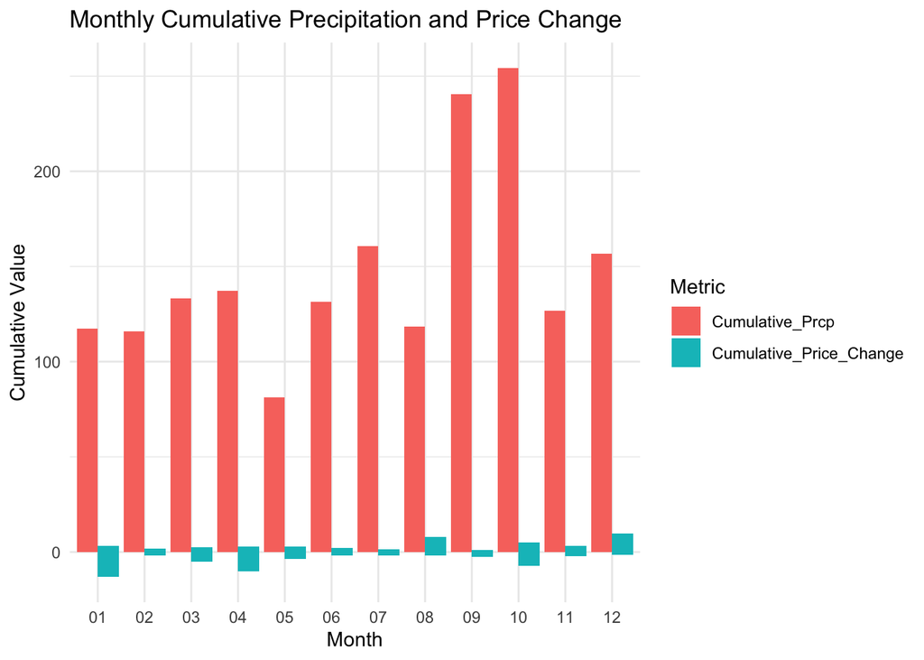

> This analytical visualization aims to reveal potential correlations between monthly cumulative precipitation in New York City and cumulative variations in NASDAQ prices. The analysis begins by importing and synchronizing datasets containing NASDAQ stock performance and NYC weather data, with date conversions ensuring alignment.The datasets are merged on matching dates, allowing for a comprehensive month-by-month comparison. Financial outcomes (gain or loss) for NASDAQ are determined by the day’s opening and closing stock prices, providing insights into market dynamics.The histograms are generated to plot cumulative values: one representing the total monthly precipitation (in millimeters) and the other depicting the cumulative price movement within the NASDAQ index. This dual-histogram setup is designed to explore whether there is a direct proportional relationship between increased precipitation and NASDAQ price fluctuations, suggesting that environmental factors might influence market performance.

## 0.5 Scatter Plot of Precipitation and Price Difference from Open to Low

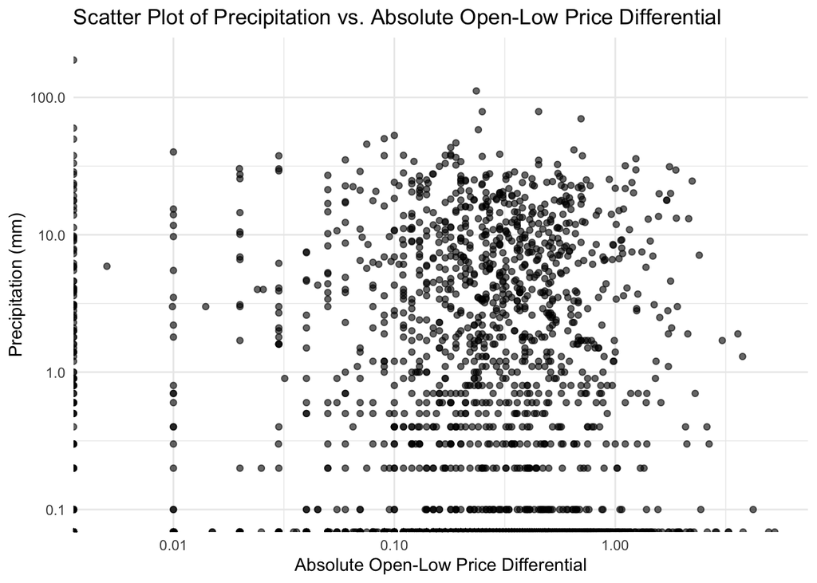

## 0.6 Scatter Plot of Precipitation and Price Difference from Open to Close

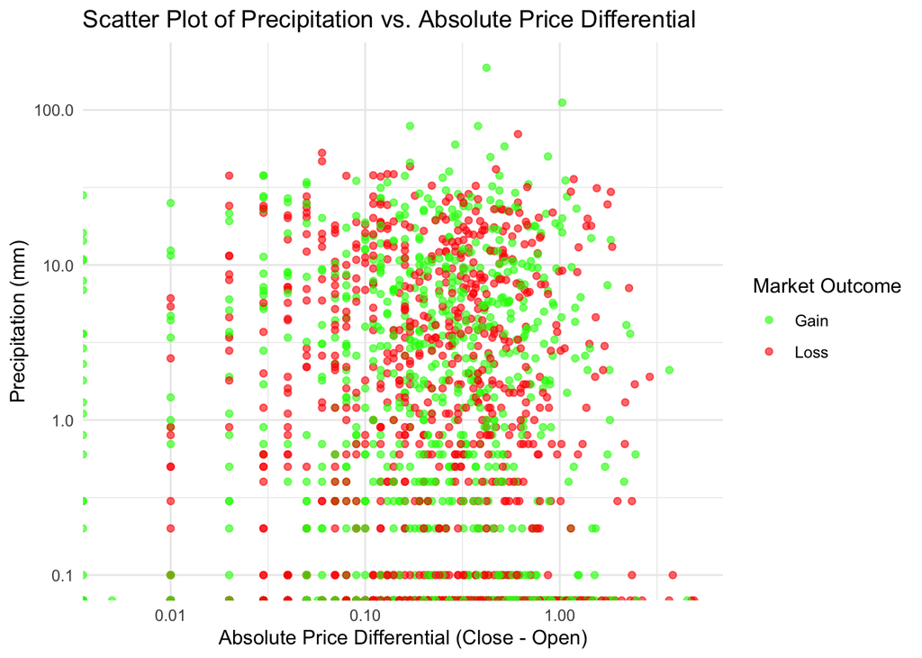

## 0.7 Separate Scatter Plots of Precipitation and Price Difference based on Gain/Loss with Regression Line

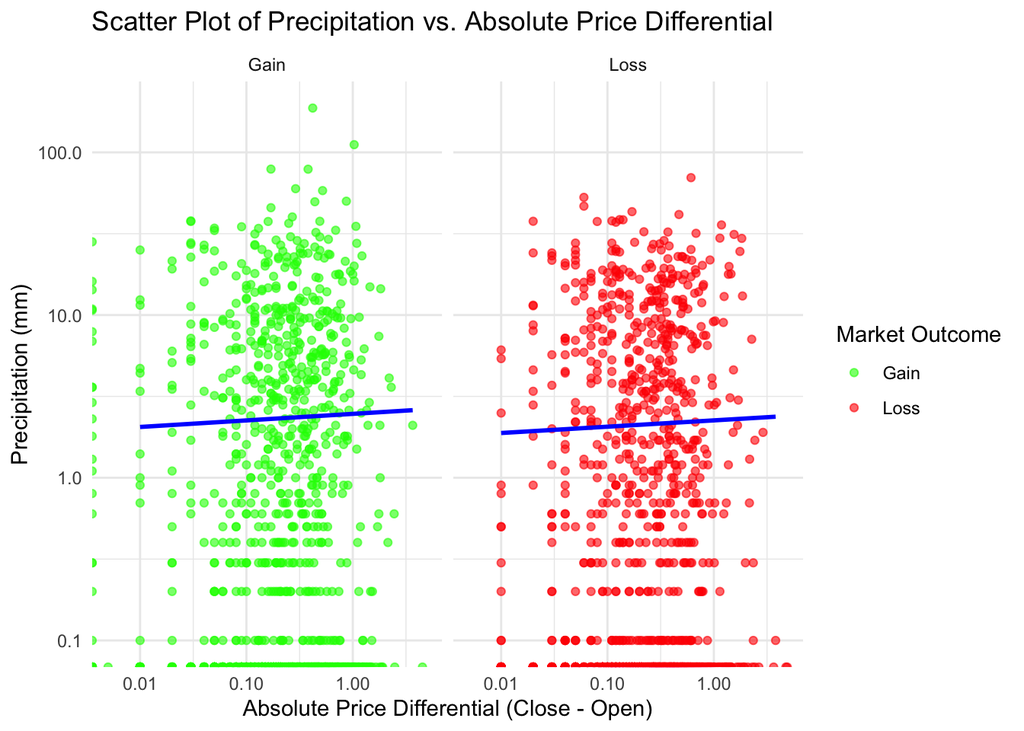

> This graph separates the data into two scatter plots—one for market gain days and one for loss days—each against the backdrop of precipitation levels, with logarithmic scales applied. The inclusion of regression lines attempts to quantify any potential relationship. While the power law model could potentially describe broader trends in this complex system, the regression lines indicate minimal influence of rainfall on market direction.

## 0.8 95% Confidence Interval Analysis and Interpretation

> Null Hypothesis (H0): The effect of precipitation on the NASDAQ price differential is 0.5. This means that for every unit increase in precipitation, the price differential increases by 0.5. We chose 0.5 previous studies have used this benchmark to determine statistical significance and we thought this would be a good measure. Alternative Hypothesis (HA): The effect of precipitation on the NASDAQ price differential is not equal to 0.5. This can be a two-sided test. Statistical Model: Linear regression where price differential depends on precipitation. Price Differential= Beta0 + Beta1 * Prcp+ Price Differential Here, Beta1is the coefficient we are testing, with the null hypothesis Beta1 = 0.5

```
## The 95% Confidence Interval for the effect of Precipitation on Price Differential is: [-0.0008, 0.0040]
```

| Statistic | Value |
| --- | --- |
| Coefficient Estimate | 0.0016 |
| Standard Error | 0.0012 |
| t-statistic | -404.6549 |
| Degrees of Freedom | 2514 |
| p-value | 0.0000e+00 |

| CI Component | Value |
| --- | --- |
| Lower Bound | -0.0008 |
| Upper Bound | 0.0040 |

## 0.10 Discussion

> Our question of interest, if rain in New York City affects the opening and closing prices of NASDAQ stocks, can be answered by looking at our graphical results. As discussed in the analysis, our graphs show no significant difference between instances of market gain or loss related to levels of precipitation. The broader interpretation of these results includes how weather affects our productivity and mood, and how weather events contribute to decision making. As we can see from the results, there is little to no effect on buying and selling decisions based on rainy weather, implying that humans do not let weather change their financial decisions, at least in the context of the stock market. As with all research, our analysis has some potential shortcomings. One of these is the concept of “causation versus correlation,” meaning that even if there were correlation between rain and the fluctuation of stock prices, it would not necessarily mean that the rain causes these fluctuations. Other factors like geopolitical events, market sentiment and economic indicators influence stock prices independently of weather events. Another potential shortcoming is confounding variables like seasonal trends, market volatility and macroeconomic factors, which could affect the stock market. Since we did not account for such factors, our analysis may not include every aspect necessary to draw a correlation between the two variables. There are many potential future directions for additional work in addressing our question of interest. If we were to do extended research on this project, we could ask the question, “How does precipitation in New York City affect the opening and closing prices of the New York Stock Exchange?” We could also extend this question to similar indexes like Dow Jones, Cboe Global Markets, or Intercontinental Exchange. These indexes’ opening and closing prices can be analyzed independently of each other, or the averages can be combined to get a deeper understanding of the stock market. Another potential question could be, “How does the UV Index in New York City affect the opening and closing prices of NASDAQ?” Changing the independent variable of our question can broaden the understanding of what weather conditions affect the stock market.  
> There are multiple methods of data analysis to answer our original question of interest that could be employed in future research. One technique is machine learning algorithms, which could analyze vast amounts of data from various sources like social media, newspapers and financial reports to interpret relationships between investor sentiment, rain and stock prices. Another tool to be used are natural language processing techniques, which would analyze textual data to find sentimental indicators of investors and assess how these sentiment changes in response to rain events.  
> New data could be collected and analyzed to broaden our question’s scope, for instance, we could include multiple types of weather data such as UV index or drought, severe storms, and heatwaves. Analyzing this type of data would allow us to draw more conclusions about what types of weather events affect the stock market. Additionally, data on investor sentiment from financial news outlets or investor surveys could enhance our understanding of what other factors may influence the opening and closing prices of NASDAQ. Overall, our analysis reveals no significant correlation between precipitation levels in New York City and the opening and closing prices of NASDAQ stocks. This can be seen through our graphical results which show no discernable difference in market performance based on varying levels of precipitation. The primary evidence is the statistics discovered through analysis in R, including the 95% confidence interval and the p-value. The 95% confidence interval of precipitation on price differential is [-0.0008, 0.0040]. This range includes the number zero, implying no statistically significant relationship. The p-value is 0.0000, which proves that the null hypothesis is false, our null hypothesis being that for every unit of increase in precipitation, the price differential would increase by 0.5.

[^1] [^2]

[^1]: https://open-meteo.com/en/docs/historical-weather-api#start_date=2014-04-10&end_date=2024-04-09&hourly=&daily=precipitation_sum&timezone=America%2FNew_York
[^2]: https://www.nasdaq.com/market-activity/stocks/csv/historical